# MovieLens_Project_Sankar_01

### Project - MovieLens Data Analysis

The GroupLens Research Project is a research group in the Department of Computer Science and Engineering at the University of Minnesota. The data is widely used for collaborative filtering and other filtering solutions. However, we will be using this data to act as a means to demonstrate our skill in using Python to “play” with data.

#### Domain

Internet and Entertainment

**Note that the project will need you to apply the concepts of groupby and merging extensively.**

## **Moviel Lens Data Analysis Project**

#### 1. Import the necessary packages - 2.5 marks

```python
import numpy as np
import pandas as pd
import seaborn as sns
import matplotlib.pyplot as plt
%matplotlib inline
import datetime
import random
import warnings
warnings.filterwarnings('ignore')
import io
```

#### 2. Read the 3 datasets into dataframes - 2.5 marks

### Uploading the files to google drive

```python
# Upload data file to Google Drive
from google.colab import files
uploaded = files.upload()
# Upload user file to Google Drive
from google.colab import files
uploaded = files.upload()
# Upload item file to Google Drive
from google.colab import files
uploaded = files.upload()
```

Upload widget is only available when the cell has been executed in the current browser session. Please rerun this cell to enable.

```
Saving data.csv to data.csv
```

Upload widget is only available when the cell has been executed in the current browser session. Please rerun this cell to enable.

```
Saving user.csv to user.csv
```

Upload widget is only available when the cell has been executed in the current browser session. Please rerun this cell to enable.

```
Saving item.csv to item.csv
```

### Importing/Reading from Goolge drive

```python
# Read data.csv from google Drive
data = pd.read_csv('data.csv')
# Read user.csv from google drive
user = pd.read_csv('user.csv')
# Read item.csv from google drive
item = pd.read_csv('item.csv')
```

#### 3. Apply info, shape, describe, and find the number of missing values in the data - 5 marks

```python
# Data.csv details
print(" Data Information :" + "\r\n")
print(data.info())
print("__________________________________________________")
print("\r\n")
print(" Data Shape :" + "\r\n")
print(data.shape)
print("__________________________________________________")
print("\r\n")
print(" Data Describtion :" + "\r\n")
print(data.describe())
print("__________________________________________________")
print("\r\n")
print(" Data Missing values :" + "\r\n")
print(data.isnull())
print("__________________________________________________")
print(" Data Total Missing values :" + "\r\n")
print(data.isnull().sum())
print("__________________________________________________")
```

```
 Data Information :

<class 'pandas.core.frame.DataFrame'>
RangeIndex: 100000 entries, 0 to 99999
Data columns (total 4 columns):
 #   Column     Non-Null Count   Dtype
---  ------     --------------   -----
 0   user id    100000 non-null  int64
 1   movie id   100000 non-null  int64
 2   rating     100000 non-null  int64
 3   timestamp  100000 non-null  int64
dtypes: int64(4)
memory usage: 3.1 MB
None
__________________________________________________


 Data Shape :

(100000, 4)
__________________________________________________


 Data Describtion :

            user id       movie id         rating     timestamp
count  100000.00000  100000.000000  100000.000000  1.000000e+05
mean      462.48475     425.530130       3.529860  8.835289e+08
std       266.61442     330.798356       1.125674  5.343856e+06
min         1.00000       1.000000       1.000000  8.747247e+08
25%       254.00000     175.000000       3.000000  8.794487e+08
50%       447.00000     322.000000       4.000000  8.828269e+08
75%       682.00000     631.000000       4.000000  8.882600e+08
max       943.00000    1682.000000       5.000000  8.932866e+08
__________________________________________________


 Data Missing values :

       user id  movie id  rating  timestamp
0        False     False   False      False
1        False     False   False      False
2        False     False   False      False
3        False     False   False      False
4        False     False   False      False
...        ...       ...     ...        ...
99995    False     False   False      False
99996    False     False   False      False
99997    False     False   False      False
99998    False     False   False      False
99999    False     False   False      False

[100000 rows x 4 columns]
__________________________________________________
 Data Total Missing values :

user id      0
movie id     0
rating       0
timestamp    0
dtype: int64
__________________________________________________
```

```python
# User.csv details
print(" User Information :" + "\r\n")
print(user.info())
print("__________________________________________________")
print("\r\n")
print(" User Shape :" + "\r\n")
print(user.shape)
print("__________________________________________________")
print("\r\n")
print(" User Describtion :" + "\r\n")
print(user.describe())
print("__________________________________________________")
print("\r\n")
print(" User Missing values :" + "\r\n")
print(user.isnull())
print("__________________________________________________")
print(" User Total Missing values :" + "\r\n")
print(user.isnull().sum())
print("__________________________________________________")
```

```
 User Information :

<class 'pandas.core.frame.DataFrame'>
RangeIndex: 943 entries, 0 to 942
Data columns (total 5 columns):
 #   Column      Non-Null Count  Dtype
---  ------      --------------  -----
 0   user id     943 non-null    int64
 1   age         943 non-null    int64
 2   gender      943 non-null    object
 3   occupation  943 non-null    object
 4   zip code    943 non-null    object
dtypes: int64(2), object(3)
memory usage: 37.0+ KB
None
__________________________________________________


 User Shape :

(943, 5)
__________________________________________________


 User Describtion :

          user id         age
count  943.000000  943.000000
mean   472.000000   34.051962
std    272.364951   12.192740
min      1.000000    7.000000
25%    236.500000   25.000000
50%    472.000000   31.000000
75%    707.500000   43.000000
max    943.000000   73.000000
__________________________________________________


 User Missing values :

```

[output cut: 9 more lines]

```
940    False  False   False       False     False
941    False  False   False       False     False
942    False  False   False       False     False

[943 rows x 5 columns]
__________________________________________________
 User Total Missing values :

user id       0
age           0
gender        0
occupation    0
zip code      0
dtype: int64
__________________________________________________
```

```python
# Item.csv details
print(" Item Information :" + "\r\n")
print(item.info())
print("__________________________________________________")
print("\r\n")
print(" Item Shape :" + "\r\n")
print(item.shape)
print("__________________________________________________")
print("\r\n")
print(" Item Describtion :" + "\r\n")
print(item.describe())
print("__________________________________________________")
print("\r\n")
print(" Item Missing values :" + "\r\n")
print(item.isnull())
print("__________________________________________________")
print(" Item Total Missing values :" + "\r\n")
print(item.isnull().sum())
print("__________________________________________________")
```

[output not shown]

#### 4. Find the number of movies per genre using the item data - 5 marks

```python
# use sum on the default axis
```

```python
item.columns
```

```
Index(['movie id', 'movie title', 'release date', 'unknown', 'Action',
       'Adventure', 'Animation', 'Childrens', 'Comedy', 'Crime', 'Documentary',
       'Drama', 'Fantasy', 'Film-Noir', 'Horror', 'Musical', 'Mystery',
       'Romance', 'Sci-Fi', 'Thriller', 'War', 'Western'],
      dtype='object')
```

```python
genrelist = ['unknown', 'Action', 'Adventure', 'Animation', 'Childrens', 'Comedy', 'Crime', 'Documentary','Drama', 'Fantasy', 'Film-Noir', 'Horror', 'Musical', 'Mystery',
'Romance', 'Sci-Fi', 'Thriller', 'War', 'Western']
print(genrelist)
formatlist =[]
for i in genrelist:
  total =item[[i]].sum()
  formatlist.append(total)
print(formatlist)
print("There is one Genre whis is marked as Unknown")
```

```
['unknown', 'Action', 'Adventure', 'Animation', 'Childrens', 'Comedy', 'Crime', 'Documentary', 'Drama', 'Fantasy', 'Film-Noir', 'Horror', 'Musical', 'Mystery', 'Romance', 'Sci-Fi', 'Thriller', 'War', 'Western']
[unknown    1
dtype: int64, Action    251
dtype: int64, Adventure    135
dtype: int64, Animation    42
dtype: int64, Childrens    122
dtype: int64, Comedy    505
dtype: int64, Crime    109
dtype: int64, Documentary    50
dtype: int64, Drama    725
dtype: int64, Fantasy    22
dtype: int64, Film-Noir    24
dtype: int64, Horror    92
dtype: int64, Musical    56
dtype: int64, Mystery    61
dtype: int64, Romance    247
dtype: int64, Sci-Fi    101
dtype: int64, Thriller    251
dtype: int64, War    71
dtype: int64, Western    27
dtype: int64]
There is one Genre whis is marked as Unknown
```

#### 5. Find the movies that have more than one genre - 2.5 marks

```python
#hint: use sum on the axis = 1
```

```python
item.columns
```

```
Index(['movie id', 'movie title', 'release date', 'unknown', 'Action',
       'Adventure', 'Animation', 'Childrens', 'Comedy', 'Crime', 'Documentary',
       'Drama', 'Fantasy', 'Film-Noir', 'Horror', 'Musical', 'Mystery',
       'Romance', 'Sci-Fi', 'Thriller', 'War', 'Western'],
      dtype='object')
```

```python
#copying item data frame to new dataframe
cp_item = item[['movie id', 'movie title']]
print(cp_item)
cp_item["genre_types_tot"]= item[['movie title', 'unknown', 'Action',
       'Adventure', 'Animation', 'Childrens', 'Comedy', 'Crime', 'Documentary',
       'Drama', 'Fantasy', 'Film-Noir', 'Horror', 'Musical', 'Mystery',
       'Romance', 'Sci-Fi', 'Thriller', 'War', 'Western']].sum(axis=1)
#for i in cp_item["genre_types.tot"]:
#  if i > 1:
#   print(cp_item)
cp_item[cp_item['genre_types_tot']>1]
```

```
      movie id                          movie title
0            1                           Toy Story
1            2                           GoldenEye
2            3                          Four Rooms
3            4                          Get Shorty
4            5                             Copycat
...        ...                                  ...
1676      1678                          Mat' i syn
1677      1679                           B. Monkey
1678      1680                       Sliding Doors
1679      1681                        You So Crazy
1680      1682  Scream of Stone (Schrei aus Stein)

[1681 rows x 2 columns]
```

|  | movie id | movie title | genre_types_tot |
| --- | --- | --- | --- |
| 0 | 1 | Toy Story | 3 |
| 1 | 2 | GoldenEye | 3 |
| 3 | 4 | Get Shorty | 3 |
| 4 | 5 | Copycat | 3 |
| 6 | 7 | Twelve Monkeys | 2 |
| ... | ... | ... | ... |
| 1667 | 1669 | MURDER and murder | 3 |
| 1668 | 1670 | Tainted | 2 |
| 1671 | 1673 | Mirage | 2 |
| 1677 | 1679 | B. Monkey | 2 |
| 1678 | 1680 | Sliding Doors | 2 |

849 rows × 3 columns

#### 6. Drop the movie where the genre is unknown - 2.5 marks

```python
item.drop('unknown', axis=1)
```

|  | movie id | movie title | release date | Action | Adventure | Animation | Childrens | Comedy | Crime | Documentary | Drama | Fantasy | Film-Noir | Horror | Musical | Mystery | Romance | Sci-Fi | Thriller | War | Western |
| --- | --- | --- | --- | --- | --- | --- | --- | --- | --- | --- | --- | --- | --- | --- | --- | --- | --- | --- | --- | --- | --- |
| 0 | 1 | Toy Story | 01-Jan-1995 | 0 | 0 | 1 | 1 | 1 | 0 | 0 | 0 | 0 | 0 | 0 | 0 | 0 | 0 | 0 | 0 | 0 | 0 |
| 1 | 2 | GoldenEye | 01-Jan-1995 | 1 | 1 | 0 | 0 | 0 | 0 | 0 | 0 | 0 | 0 | 0 | 0 | 0 | 0 | 0 | 1 | 0 | 0 |
| 2 | 3 | Four Rooms | 01-Jan-1995 | 0 | 0 | 0 | 0 | 0 | 0 | 0 | 0 | 0 | 0 | 0 | 0 | 0 | 0 | 0 | 1 | 0 | 0 |
| 3 | 4 | Get Shorty | 01-Jan-1995 | 1 | 0 | 0 | 0 | 1 | 0 | 0 | 1 | 0 | 0 | 0 | 0 | 0 | 0 | 0 | 0 | 0 | 0 |
| 4 | 5 | Copycat | 01-Jan-1995 | 0 | 0 | 0 | 0 | 0 | 1 | 0 | 1 | 0 | 0 | 0 | 0 | 0 | 0 | 0 | 1 | 0 | 0 |
| ... | ... | ... | ... | ... | ... | ... | ... | ... | ... | ... | ... | ... | ... | ... | ... | ... | ... | ... | ... | ... | ... |
| 1676 | 1678 | Mat' i syn | 06-Feb-1998 | 0 | 0 | 0 | 0 | 0 | 0 | 0 | 1 | 0 | 0 | 0 | 0 | 0 | 0 | 0 | 0 | 0 | 0 |
| 1677 | 1679 | B. Monkey | 06-Feb-1998 | 0 | 0 | 0 | 0 | 0 | 0 | 0 | 0 | 0 | 0 | 0 | 0 | 0 | 1 | 0 | 1 | 0 | 0 |
| 1678 | 1680 | Sliding Doors | 01-Jan-1998 | 0 | 0 | 0 | 0 | 0 | 0 | 0 | 1 | 0 | 0 | 0 | 0 | 0 | 1 | 0 | 0 | 0 | 0 |
| 1679 | 1681 | You So Crazy | 01-Jan-1994 | 0 | 0 | 0 | 0 | 1 | 0 | 0 | 0 | 0 | 0 | 0 | 0 | 0 | 0 | 0 | 0 | 0 | 0 |
| 1680 | 1682 | Scream of Stone (Schrei aus Stein) | 08-Mar-1996 | 0 | 0 | 0 | 0 | 0 | 0 | 0 | 1 | 0 | 0 | 0 | 0 | 0 | 0 | 0 | 0 | 0 | 0 |

1681 rows × 21 columns

### 7. Univariate plots of columns: 'rating', 'Age', 'release year', 'Gender' and 'Occupation' - 10 marks

```python
# HINT: use distplot for age and countplot for gender,ratings,occupation.
# HINT: Please refer to the below snippet to understand how to get to release year from release date. You can use str.split()
# as depicted below
# Hint : Use displot without kde for release year or line plot showing year wise count.
```

```python
a = 'My*cat*is*brown'
print(a.split('*')[3])

#similarly, the release year needs to be taken out from release date

#also you can simply slice existing string to get the desired data, if we want to take out the colour of the cat

print(a[10:])
print(a[-5:])
```

[output not shown]

```
<function matplotlib.pyplot.show>
```

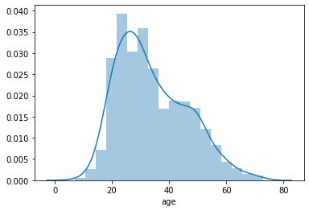

```python
#For AGE
sns.distplot(user['age'])
plt.show
```

```
<function matplotlib.pyplot.show>
```

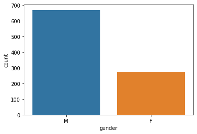

```python
#For Gender
sns.countplot(user['gender'])
plt.show
```

```
<function matplotlib.pyplot.show>
```

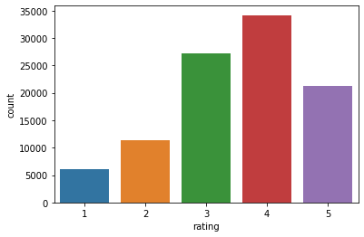

```python
#For Rating
sns.countplot(data['rating'])
plt.show
```

```
<function matplotlib.pyplot.show>
```

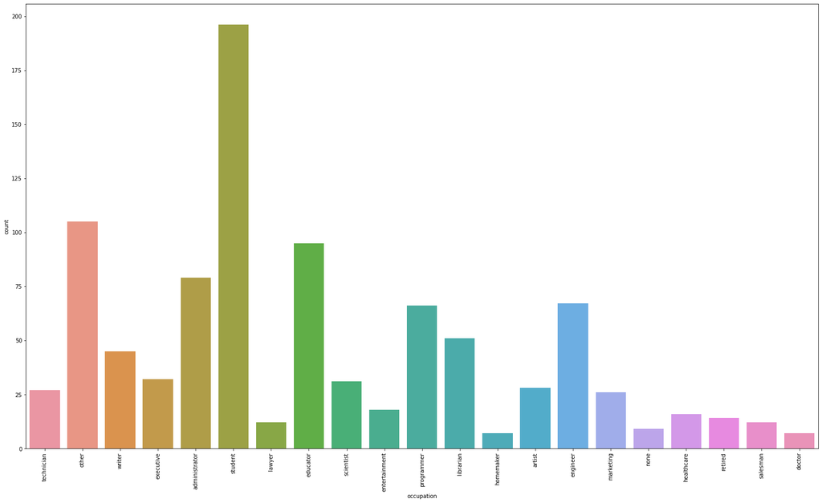

```python
# For Occupation
plt.figure(figsize=(26,15))
sns.countplot(user['occupation'])
plt.xticks(rotation=90)
plt.show
```

```
<function matplotlib.pyplot.show>
```

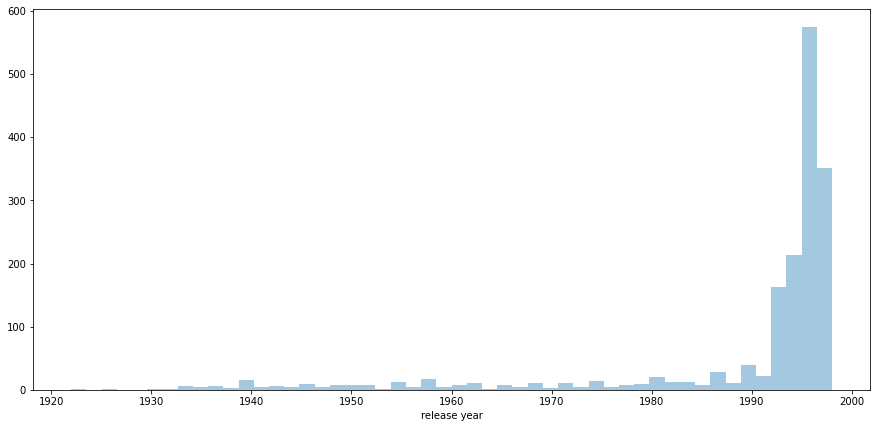

```python
# For Release year
#Formating year
cp_item_year = item
cp_item_year['release year'] = item['release date'].str[-4:].astype('int')
# ploting
plt.figure(figsize=(15,7))
sns.distplot(cp_item_year['release year'],kde=False)
plt.show
```

### 8. Visualize how popularity of genres has changed over the years - 10 marks

Note that you need to use the number of releases in a year as a parameter of popularity of a genre

Hint

1: you need to reach to a data frame where the release year is the index and the genre is the column names (one cell shows the number of release in a year in one genre) or vice versa. Once that is achieved, you can either use univariate plots or can use the heatmap to visualise all the changes over the years in one go.

Hint 2: Use groupby on the relevant column and use sum() on the same to find out the nuumber of releases in a year/genre.

```python
#Your answer here
gen_yr = item.groupby('release year').sum()
#droping movieid and transpose the dataframe
#gen_yr = gen_yr.drop(columns='movie id').transpose
gen_yr = gen_yr.drop(columns='movie id').T #better output display
gen_yr
```

| release year | 1922 | 1926 | 1930 | 1931 | 1932 | 1933 | 1934 | 1935 | 1936 | 1937 | 1938 | 1939 | 1940 | 1941 | 1942 | 1943 | 1944 | 1945 | 1946 | 1947 | 1948 | 1949 | 1950 | 1951 | 1952 | 1953 | 1954 | 1955 | 1956 | … |
| --- | --- | --- | --- | --- | --- | --- | --- | --- | --- | --- | --- | --- | --- | --- | --- | --- | --- | --- | --- | --- | --- | --- | --- | --- | --- | --- | --- | --- | --- | --- |
| unknown | 0 | 0 | 0 | 0 | 0 | 0 | 0 | 0 | 0 | 0 | 0 | 0 | 0 | 0 | 0 | 0 | 0 | 0 | 0 | 0 | 0 | 0 | 0 | 0 | 0 | 0 | 0 | 0 | 0 | … |
| Action | 0 | 0 | 0 | 0 | 0 | 0 | 0 | 0 | 0 | 0 | 1 | 0 | 0 | 0 | 0 | 0 | 0 | 0 | 0 | 0 | 0 | 0 | 0 | 1 | 0 | 0 | 1 | 0 | 0 | … |
| Adventure | 0 | 0 | 0 | 0 | 0 | 0 | 0 | 0 | 0 | 0 | 1 | 1 | 1 | 0 | 0 | 1 | 0 | 0 | 0 | 1 | 1 | 0 | 0 | 1 | 0 | 0 | 1 | 0 | 1 | … |
| Animation | 0 | 0 | 0 | 0 | 0 | 0 | 0 | 0 | 0 | 1 | 0 | 0 | 2 | 1 | 0 | 0 | 0 | 1 | 0 | 0 | 0 | 0 | 1 | 1 | 0 | 0 | 0 | 0 | 0 | … |
| Childrens | 0 | 0 | 0 | 0 | 0 | 0 | 0 | 0 | 0 | 1 | 0 | 2 | 2 | 1 | 0 | 0 | 0 | 1 | 0 | 0 | 0 | 1 | 2 | 1 | 0 | 0 | 1 | 0 | 0 | … |
| Comedy | 0 | 0 | 0 | 0 | 0 | 1 | 2 | 2 | 1 | 2 | 1 | 2 | 3 | 0 | 1 | 1 | 1 | 0 | 0 | 0 | 0 | 0 | 1 | 0 | 1 | 2 | 2 | 1 | 1 | … |
| Crime | 0 | 0 | 0 | 1 | 0 | 0 | 0 | 0 | 0 | 0 | 0 | 1 | 0 | 0 | 0 | 0 | 1 | 0 | 1 | 1 | 1 | 0 | 0 | 0 | 0 | 0 | 0 | 0 | 0 | … |
| Documentary | 0 | 0 | 0 | 0 | 0 | 0 | 0 | 0 | 0 | 0 | 0 | 0 | 0 | 0 | 0 | 0 | 0 | 0 | 0 | 0 | 0 | 0 | 0 | 0 | 0 | 0 | 0 | 0 | 0 | … |
| Drama | 0 | 1 | 1 | 0 | 0 | 0 | 1 | 0 | 1 | 1 | 1 | 5 | 0 | 3 | 2 | 1 | 0 | 1 | 3 | 1 | 0 | 2 | 3 | 2 | 0 | 0 | 3 | 3 | 2 | … |
| Fantasy | 0 | 0 | 0 | 0 | 0 | 0 | 0 | 0 | 0 | 0 | 0 | 0 | 0 | 0 | 0 | 0 | 0 | 0 | 0 | 0 | 0 | 0 | 0 | 0 | 0 | 0 | 1 | 0 | 0 | … |
| Film-Noir | 0 | 0 | 0 | 1 | 0 | 0 | 0 | 0 | 0 | 0 | 0 | 0 | 0 | 1 | 0 | 0 | 2 | 0 | 2 | 2 | 2 | 0 | 1 | 0 | 0 | 0 | 0 | 0 | 0 | … |
| Horror | 1 | 0 | 0 | 0 | 0 | 0 | 0 | 1 | 0 | 0 | 0 | 0 | 0 | 0 | 0 | 0 | 0 | 1 | 0 | 0 | 0 | 0 | 0 | 0 | 0 | 0 | 0 | 0 | 0 | … |
| Musical | 0 | 0 | 0 | 0 | 0 | 0 | 1 | 1 | 0 | 3 | 0 | 1 | 1 | 1 | 0 | 0 | 1 | 1 | 0 | 0 | 0 | 1 | 1 | 2 | 1 | 1 | 0 | 0 | 0 | … |
| Mystery | 0 | 0 | 0 | 0 | 0 | 0 | 1 | 0 | 0 | 0 | 0 | 0 | 0 | 1 | 0 | 1 | 3 | 1 | 1 | 0 | 0 | 1 | 1 | 0 | 0 | 0 | 2 | 0 | 0 | … |
| Romance | 0 | 0 | 0 | 0 | 1 | 1 | 1 | 1 | 0 | 2 | 0 | 2 | 2 | 1 | 1 | 0 | 0 | 1 | 1 | 2 | 0 | 0 | 0 | 2 | 2 | 1 | 1 | 1 | 0 | … |
| Sci-Fi | 0 | 0 | 0 | 0 | 0 | 0 | 0 | 0 | 0 | 0 | 0 | 0 | 0 | 0 | 0 | 0 | 0 | 0 | 0 | 0 | 0 | 0 | 0 | 1 | 0 | 0 | 1 | 0 | 1 | … |
| Thriller | 0 | 0 | 0 | 1 | 0 | 0 | 0 | 1 | 0 | 0 | 0 | 0 | 2 | 0 | 0 | 0 | 3 | 1 | 1 | 0 | 1 | 1 | 0 | 0 | 0 | 0 | 2 | 1 | 0 | … |
| War | 0 | 0 | 0 | 0 | 1 | 1 | 0 | 0 | 0 | 0 | 0 | 1 | 0 | 0 | 2 | 1 | 0 | 0 | 0 | 0 | 0 | 0 | 0 | 1 | 0 | 0 | 0 | 0 | 0 | … |
| Western | 0 | 0 | 0 | 0 | 0 | 0 | 0 | 0 | 0 | 0 | 0 | 0 | 0 | 0 | 0 | 1 | 0 | 0 | 0 | 1 | 0 | 0 | 0 | 0 | 1 | 0 | 1 | 1 | 0 | … |

```
<function matplotlib.pyplot.show>
```

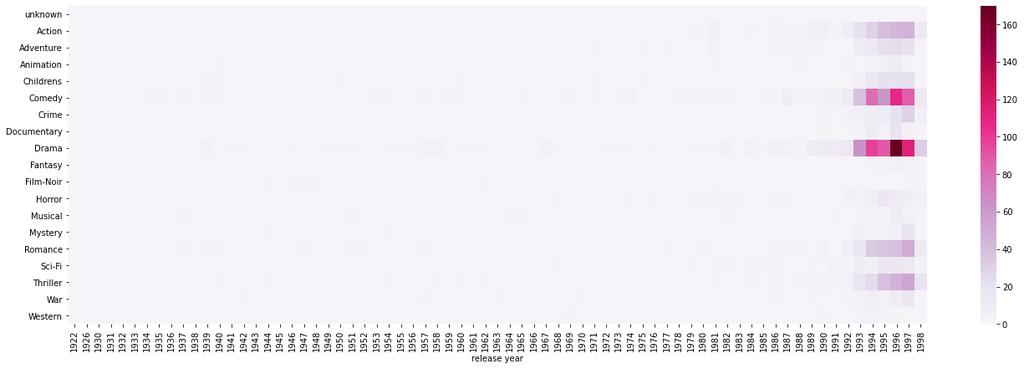

```python
# Heat Map generation
plt.figure(figsize=(23,7))
#sns.heatmap(gen_yr,cmap="BuPu" )
sns.heatmap(gen_yr,cmap="PuRd" )
plt.show
```

Hint :

1. First find the movies that have more than 100 ratings(use merge, groupby and count). Extract the movie titles in a list.
2. Find the average rating of all the movies and sort them in the descending order. You will have to use the .merge() function to reach to a data set through which you can get the names and the average rating.
3. Use isin(list obtained from 1) to filter out the movies which have more than 100 ratings.

Note: This question will need you to research about groupby and apply your findings. You can find more on groupby on https://realpython.com/pandas-groupby/.

```python
# extract movies have more than 100 ratings

# merging user and data frames together into new dataframe
merg_usr_dat  = user.merge(data,on='user id',how='inner')
merg_usr_dat
# mergin all 3 dataframes together
merg_all = merg_usr_dat.merge(item,on='movie id', how ='inner')
merg_all.head()

movie_list = merg_all['movie title'].tolist()
movie_list.count("Groundhog Day ")
movie_grp = merg_all.groupby(['movie id','movie title'])['rating'].count()
movie_grp
```

```
movie id  movie title
1         Toy Story                              452
2         GoldenEye                              131
3         Four Rooms                              90
4         Get Shorty                             209
5         Copycat                                 86
                                                ...
1678      Mat' i syn                               1
1679      B. Monkey                                1
1680      Sliding Doors                            1
1681      You So Crazy                             1
1682      Scream of Stone (Schrei aus Stein)       1
Name: rating, Length: 1681, dtype: int64
```

### 10. See gender distribution across different genres check for the validity of the below statements - 10 marks

- Men watch more drama than women
- Women watch more Sci-Fi than men
- Men watch more Romance than women
1. There is no need to conduct statistical tests around this. Just compare the percentages and comment on the validity of the above statements.
2. you might want ot use the .sum(), .div() function here.
3. Use number of ratings to validate the numbers. For example, if out of 4000 ratings received by women, 3000 are for drama, we will assume that 75% of the women watch drama.

```python
gen_gender = merg_all.groupby('gender').sum().loc[:,'Action':'Western']
gen_gender['total'] = gen_gender.sum(axis = 1)
print(gen_gender.T)
print('_____________________________________________________________________')
print("In total Male watch more movies than Female")
print('_____________________________________________________________________')
gen_gender.div(gen_gender.total, axis =0)*100
```

```
gender           F       M
Action        5442   20147
Adventure     3141   10612
Animation      995    2610
Childrens     2232    4950
Comedy        8068   21764
Crime         1794    6261
Documentary    187     571
Drama        11008   28887
Fantasy        363     989
Film-Noir      385    1348
Horror        1197    4120
Musical       1442    3512
Mystery       1314    3931
Romance       5858   13603
Sci-Fi        2629   10101
Thriller      5086   16786
War           2189    7209
Western        371    1483
total        53701  158884
_____________________________________________________________________
In total Male watch more movies than Female
_____________________________________________________________________
```

| gender | Action | Adventure | Animation | Childrens | Comedy | Crime | Documentary | Drama | Fantasy | Film-Noir | Horror | Musical | Mystery | Romance | Sci-Fi | Thriller | War | Western | total |
| --- | --- | --- | --- | --- | --- | --- | --- | --- | --- | --- | --- | --- | --- | --- | --- | --- | --- | --- | --- |
| F | 10.133889 | 5.849053 | 1.852852 | 4.156347 | 15.023929 | 3.340720 | 0.348224 | 20.498687 | 0.675965 | 0.716933 | 2.229009 | 2.685239 | 2.446882 | 10.908549 | 4.895626 | 9.47096 | 4.076274 | 0.690862 | 100.0 |
| M | 12.680320 | 6.679087 | 1.642708 | 3.115480 | 13.698044 | 3.940611 | 0.359382 | 18.181189 | 0.622467 | 0.848418 | 2.593087 | 2.210418 | 2.474132 | 8.561592 | 6.357468 | 10.56494 | 4.537272 | 0.933385 | 100.0 |

## Men watch more Romance than women = False : F = 10.9%, M = 8.56%